# Difference between Two Rates

Lee & Wagenmakers Part II. 3.2, p39

cn

2023-03-23

```r
set.seed(12345)

if (!require("pacman", quietly = TRUE)) install.packages("pacman")
if (!require("rjags", quietly = TRUE)) install.packages("rjags")
pacman::p_load(R2jags, psych)
pacman::p_load_gh("RLesur/klippy")

klippy::klippy()
```

# 1 Running MCMC

## 1.1 Setups

자료와 변수, 초기값, 파라미터를 설정한다. 이진적 결과가 나오는 10회 시행을 두 차례 실시했을 때, 특정 값이 각각 5번과 7번 산출되었다. 이제 해당 반응의 비율 *theta* 파라미터를 한 개의 체인에서 표집해보자.

```r
# 자료
k1 <- 5
k2 <- 7
n1 <- 10
n2 <- 10

data <- list("k1", "k2", "n1", "n2") # to be passed on to JAGS
myinits <-  list(
  list(theta1 = 0.1, theta2 = 0.9))

# 관찰할 파라미터(parameters to be monitored):
parameters <- c("delta", "theta1", "theta2")
```

## 1.2 Model & MCMC

```r
model_text <- "
# Difference Between Two Rates
model{
   # Observed Counts
   k1 ~ dbin(theta1,n1)
   k2 ~ dbin(theta2,n2)
   # Prior on Rates
   theta1 ~ dbeta(1,1)
   theta2 ~ dbeta(1,1)
   # Difference Between Rates
   delta <- theta1-theta2
}
"

samples <- jags(data, inits=myinits, parameters,
                 model.file = textConnection(model_text),
                 n.chains=1, n.iter=10000,
         n.burnin=1, n.thin=1, DIC=T)
```

```
## module glm loaded
```

이제 관찰한 파라미터의 값들이 **samples** 객체에 저장되었으니 자세히 살펴보자.

# 2 Visualization

## 2.1 Raw codes

```r
print(samples)
```

```
## Inference for Bugs model at "4", fit using jags,
##  1 chains, each with 10000 iterations (first 1 discarded)
##  n.sims = 9999 iterations saved
##          mu.vect sd.vect   2.5%    25%    50%    75%  97.5%
## delta     -0.163   0.191 -0.522 -0.298 -0.167 -0.036  0.217
## theta1     0.501   0.139  0.231  0.403  0.501  0.600  0.772
## theta2     0.664   0.134  0.384  0.574  0.674  0.764  0.891
## deviance   7.241   1.784  5.493  5.961  6.698  7.933 12.023
##
## DIC info (using the rule, pD = var(deviance)/2)
## pD = 1.6 and DIC = 8.8
## DIC is an estimate of expected predictive error (lower deviance is better).
```

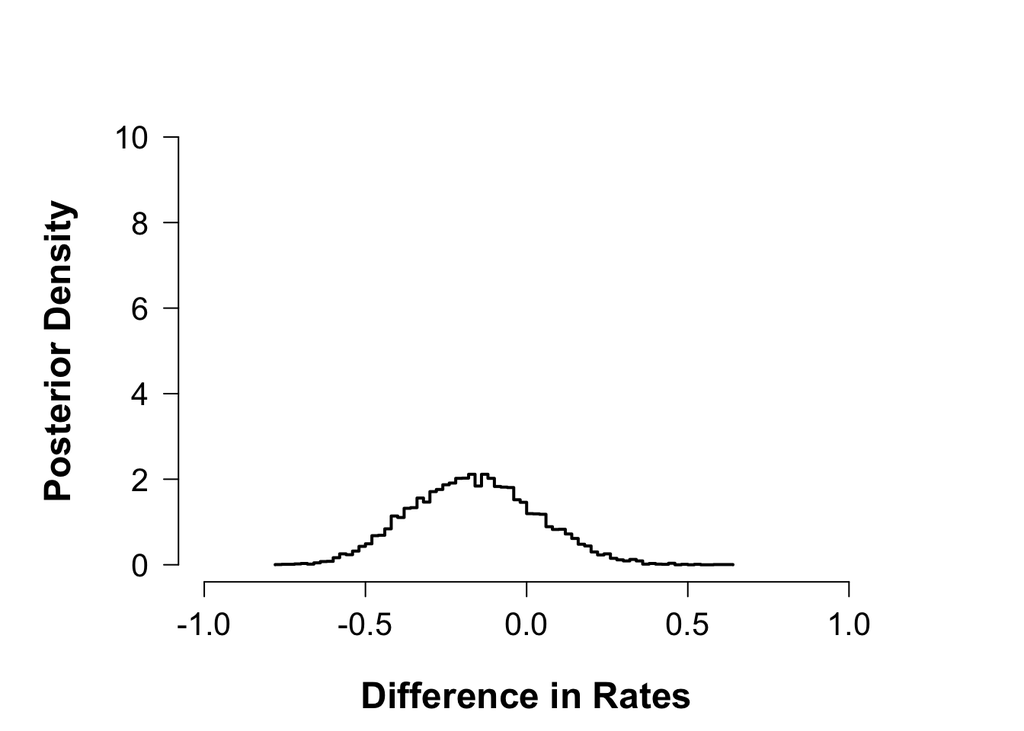

```r
delta <- samples$BUGSoutput$sims.list$delta

par(cex.main = 1.5, mar = c(5, 6, 4, 5) + 0.1, mgp = c(3.5, 1, 0), cex.lab = 1.5,
    font.lab = 2, cex.axis = 1.3, bty = "n", las=1)
Nbreaks <- 80
y       <- hist(delta, Nbreaks, plot=F)
plot(c(y$breaks, max(y$breaks)), c(0,y$density,0), type="S", lwd=2, lty=1,
     xlim=c(-1,1), ylim=c(0,10), xlab="Difference in Rates", ylab="Posterior Density")
```

사후분포로부터 *delta*를 점추정(point estimation) 하자.

```r
# mean of delta:
mean(delta)
```

```
## [1] -0.1633753
```

```r
# median of delta:
median(delta)
```

```
## [1] -0.1669956
```

```r
# mode of delta, estimated from the "density" smoother:
density(delta)$x[which(density(delta)$y==max(density(delta)$y))]
```

```
## [1] -0.1849399
```

```r
# 95% credible interval for delta:
quantile(delta, c(.025,.975))
```

```
##       2.5%      97.5%
## -0.5215980  0.2173468
```

## 2.2 CalvinBayes

표집한 결과를 쉽게 다룰 수 있는 함수들을 제공한다. 활용 사례는 [여기](https://rpruim.github.io/Kruschke-Notes/jags-just-another-gibbs-sampler.html)를 참조할 것.  
가장 먼저 `as.mcmc()`를 통해 `samples`를 mcmc 객체로 변환한다. 이제 `plot()`으로 traceplot과 사후분포를 한꺼번에 확인할 수 있다.

```r
pacman::p_load_gh("rpruim/CalvinBayes")

# 1. 가장 먼저 coda::as.mcmc로 전체 그림을 그린다.
samples.mcmc <- as.mcmc(samples)
head(samples.mcmc)
```

```
## [[1]]
## Markov Chain Monte Carlo (MCMC) output:
## Start = 2
## End = 8
## Thinning interval = 1
##            delta deviance    theta1    theta2
## [1,] -0.52629698 8.144428 0.3016038 0.8279008
## [2,] -0.36947199 7.150353 0.3038520 0.6733240
## [3,]  0.20395441 8.940477 0.7106067 0.5066523
## [4,] -0.02676586 6.109568 0.5680602 0.5948261
## [5,] -0.19128860 5.471102 0.5209133 0.7122019
## [6,] -0.41044716 6.949255 0.3150893 0.7255364
## [7,] -0.37173533 7.585062 0.2846255 0.6563608
##
## attr(,"class")
## [1] "mcmc.list"
```

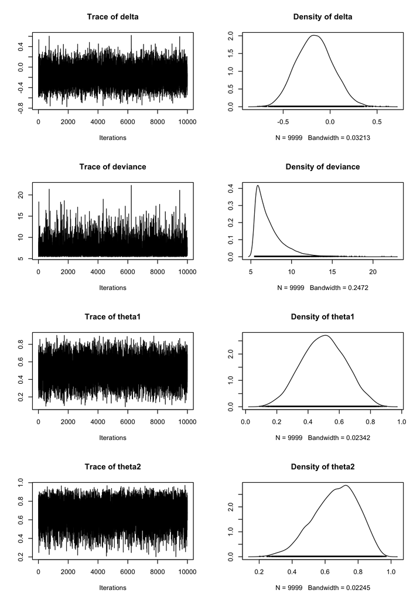

```r
plot(samples.mcmc)
```

`posterior()`는 posterior를 쓰면 samples을 쉽게 꺼낼 수 있다.

```r
p <- posterior(samples) # tidy df로 샘플 추출한다.
psych::headTail(p)
```

```
##      delta deviance theta1 theta2   chain iter
## 1    -0.53     8.14    0.3   0.83 chain:1    1
## 2    -0.37     7.15    0.3   0.67 chain:1    2
## 3      0.2     8.94   0.71   0.51 chain:1    3
## 4    -0.03     6.11   0.57   0.59 chain:1    4
## ...    ...      ...    ...    ...    <NA>  ...
## 9996 -0.37     6.24   0.37   0.74 chain:1 9996
## 9997 -0.35     6.01   0.42   0.78 chain:1 9997
## 9998  -0.2     6.34    0.4    0.6 chain:1 9998
## 9999 -0.12      7.6   0.69   0.81 chain:1 9999
```

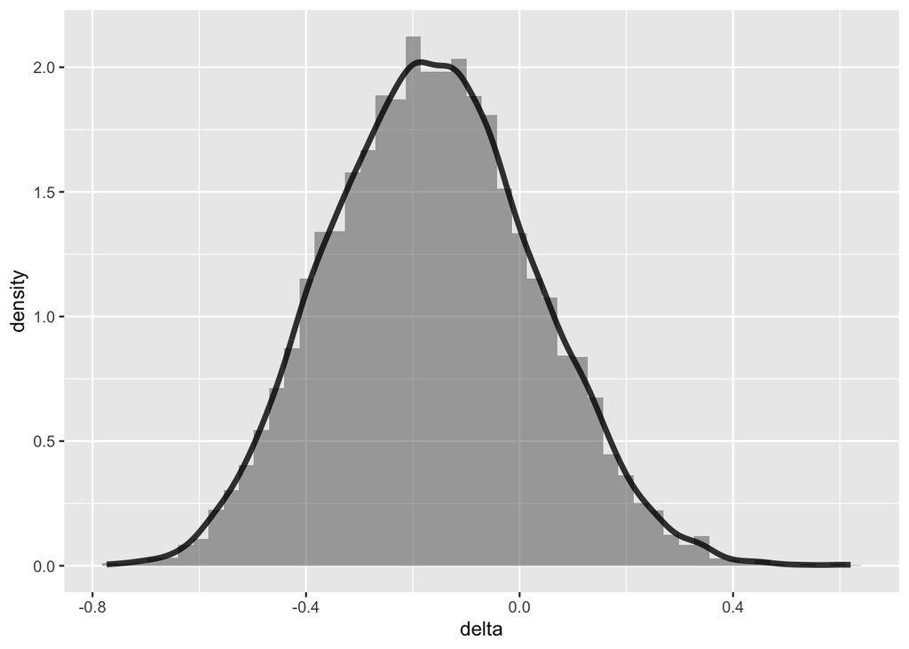

```r
# d <- as_tibble(samples$BUGSoutput$sims.matrix) # 이렇게도 할 수 있다.

p %>%
    gf_dhistogram(~delta, bins = 50) %>%
    gf_dens(~delta, size = 1.5, alpha = 0.8)
```

아래는 Kruschke 스타일의 플롯들이다. Mode와 HDI를 모두 보여준다.

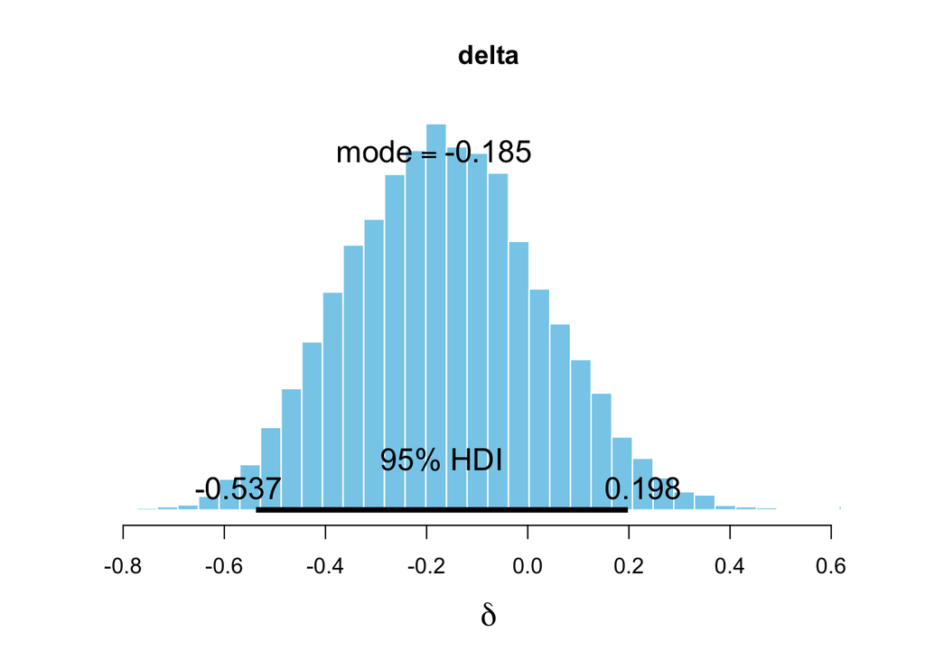

```
## $posterior
##           ESS       mean     median       mode
## var1 8521.888 -0.1633753 -0.1669956 -0.1849399
##
## $hdi
##   prob         lo        hi
## 1 0.95 -0.5373724 0.1980523
```

```r
plot_post(p$delta, main = "delta", xlab = expression(delta))
```

준거점을 제시하고 비교하는 등 더 구체적인 정보를 보여주도록 옵션을 설정할 수 있다.

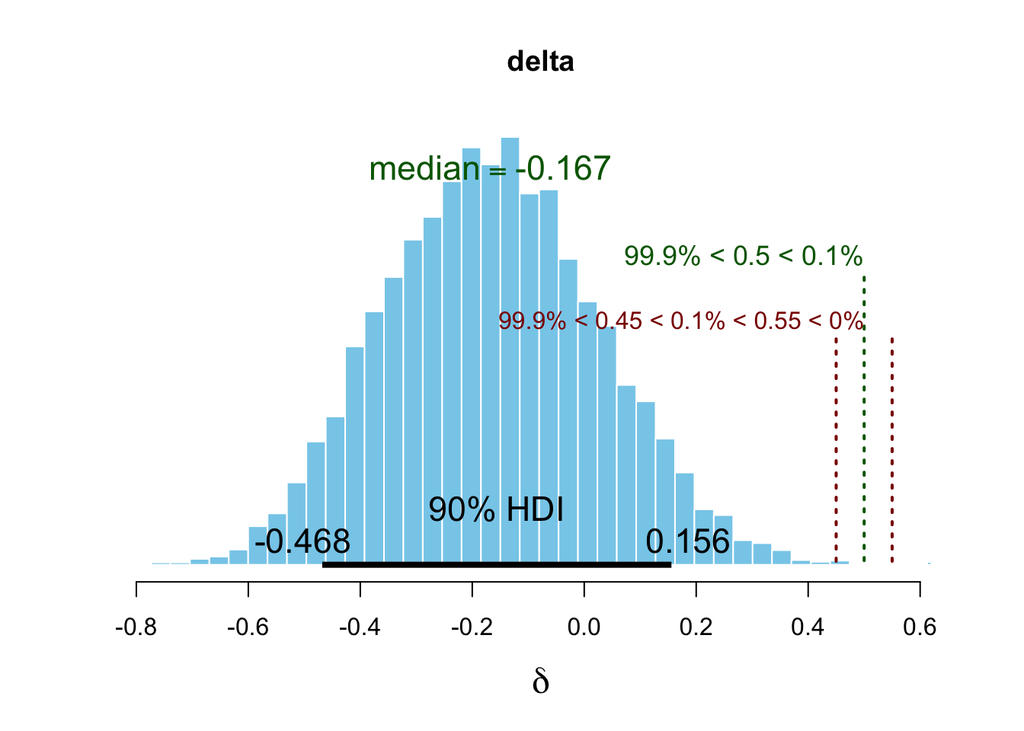

```r
plot_post(p$delta, main = "delta", xlab = expression(delta),
                    cenTend = "median", compVal = 0.5, ROPE = c(0.45, 0.55),
                    credMass = 0.90, quietly = TRUE)
```

## 2.3 GGDist

분포를 손쉽게 다룰 수 있는 계산 및 플롯 함수들을 제공한다. 활용 사례는 [여기](https://github.com/mjskay/ggdist/blob/master/figures-source/cheat_sheet-slabinterval.pdf)를 참조할 것.

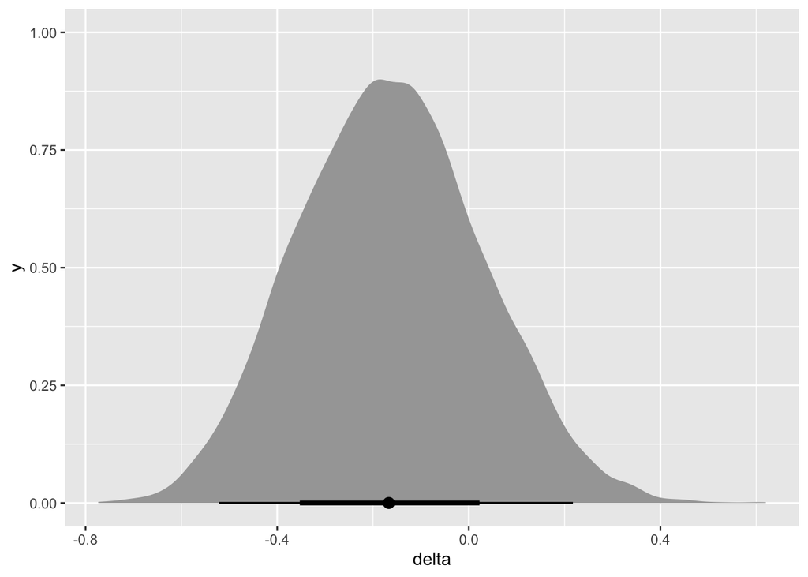

```r
pacman::p_load(tidyverse, ggdist)

p %>% ggplot(aes(x = delta)) +
    stat_halfeye()
```

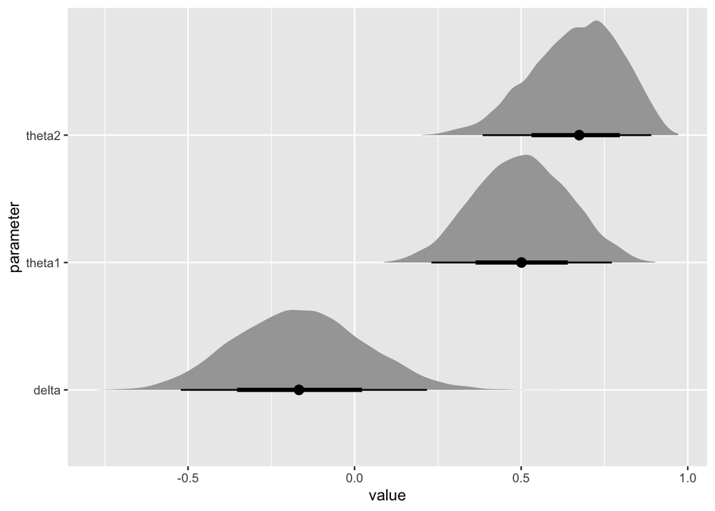

```r
p %>% unite("smpl", chain:iter) %>%
    # pivot_longer(!smpl,
    #                        names_to = "parameter",
    #                        values_to = "value") %>%
    pivot_longer(c("delta", "theta1", "theta2"),
                             names_to = "parameter",
                             values_to = "value") %>%
    ggplot(aes(y = parameter, x = value)) +
    stat_halfeye()
```

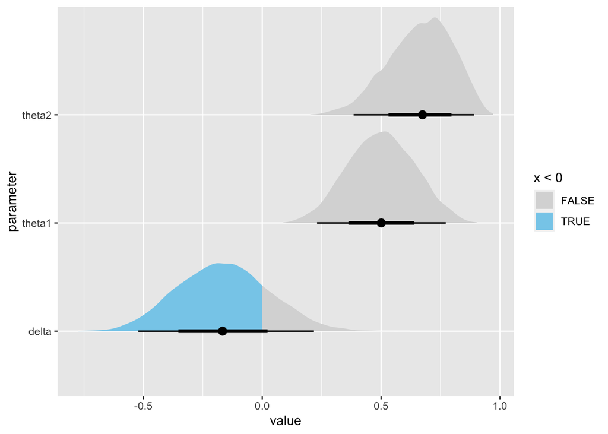

```r
p %>% unite("smpl", chain:iter) %>%
    pivot_longer(c("delta", "theta1", "theta2"),
                             names_to = "parameter",
                             values_to = "value") %>%
    ggplot(aes(y = parameter, x = value,
                         fill = stat(x < 0))) +
    stat_halfeye() +
    scale_fill_manual(values = c("gray85", "skyblue"))
```

앞에서 계산했던 대푯값을 보여주는 함수들이다.

```r
summary(p)
```

```
##      delta             deviance          theta1            theta2
##  Min.   :-0.77354   Min.   : 5.447   Min.   :0.08837   Min.   :0.2021
##  1st Qu.:-0.29812   1st Qu.: 5.961   1st Qu.:0.40267   1st Qu.:0.5742
##  Median :-0.16700   Median : 6.698   Median :0.50086   Median :0.6742
##  Mean   :-0.16338   Mean   : 7.241   Mean   :0.50081   Mean   :0.6642
##  3rd Qu.:-0.03591   3rd Qu.: 7.933   3rd Qu.:0.60005   3rd Qu.:0.7638
##  Max.   : 0.62002   Max.   :22.253   Max.   :0.90214   Max.   :0.9712
##     chain                iter
##  Length:9999        Min.   :   1
##  Class :character   1st Qu.:2500
##  Mode  :character   Median :5000
##                     Mean   :5000
##                     3rd Qu.:7500
##                     Max.   :9999
```

```r
mode_hdi(p$delta)
```

```
##            y       ymin      ymax .width .point .interval
## 1 -0.1844771 -0.5371766 0.1980523   0.95   mode       hdi
```

```r
median_qi(p$delta)
```

```
##            y      ymin      ymax .width .point .interval
## 1 -0.1669956 -0.521598 0.2173468   0.95 median        qi
```

```r
mean_qi(p$delta)
```

```
##            y      ymin      ymax .width .point .interval
## 1 -0.1633753 -0.521598 0.2173468   0.95   mean        qi
```

## 2.4 cowplot

특히 mode에 관해 흥미로운 데모들이 있다: [여기](https://bookdown.org/content/3686/markov-chain-monte-carlo.html)

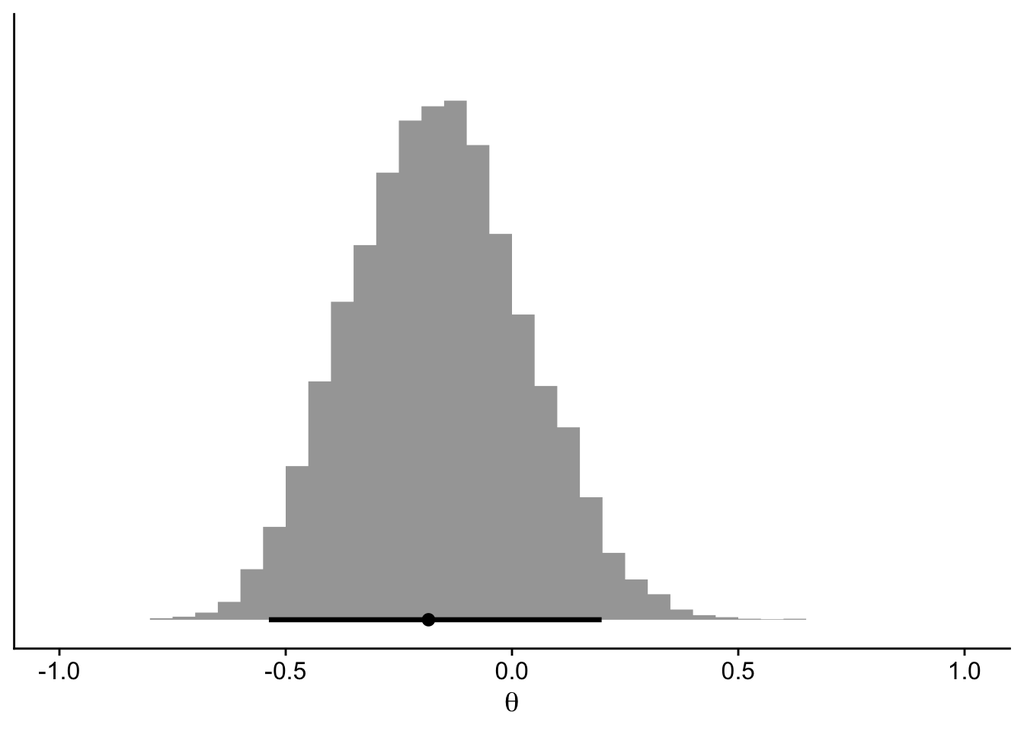

```r
pacman::p_load(cowplot)

p %>%
    ggplot(aes(x = delta, y = 0)) +
    stat_histinterval(point_interval = mode_hdi, .width = .95, breaks = 30) +
    scale_x_continuous(expression(theta), limits = c(-1, 1)) +
    scale_y_continuous(NULL, breaks = NULL) +
    theme_cowplot()
```

## 2.5 bayesplot

또 하나의 유용한 패키지이다. 활용 사례는 [여기](https://mc-stan.org/bayesplot/)와 [여기](https://mc-stan.org/bayesplot/reference/MCMC-intervals.html)를 참조할 것.

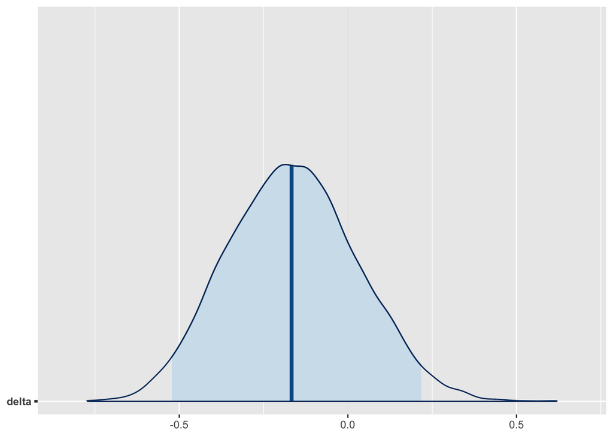

```r
library(bayesplot)
mcmc_areas(
    samples,
    pars = c("delta"),     # make a plot for the theta parameter
    prob = 0.95)           # shade the central 90%
```

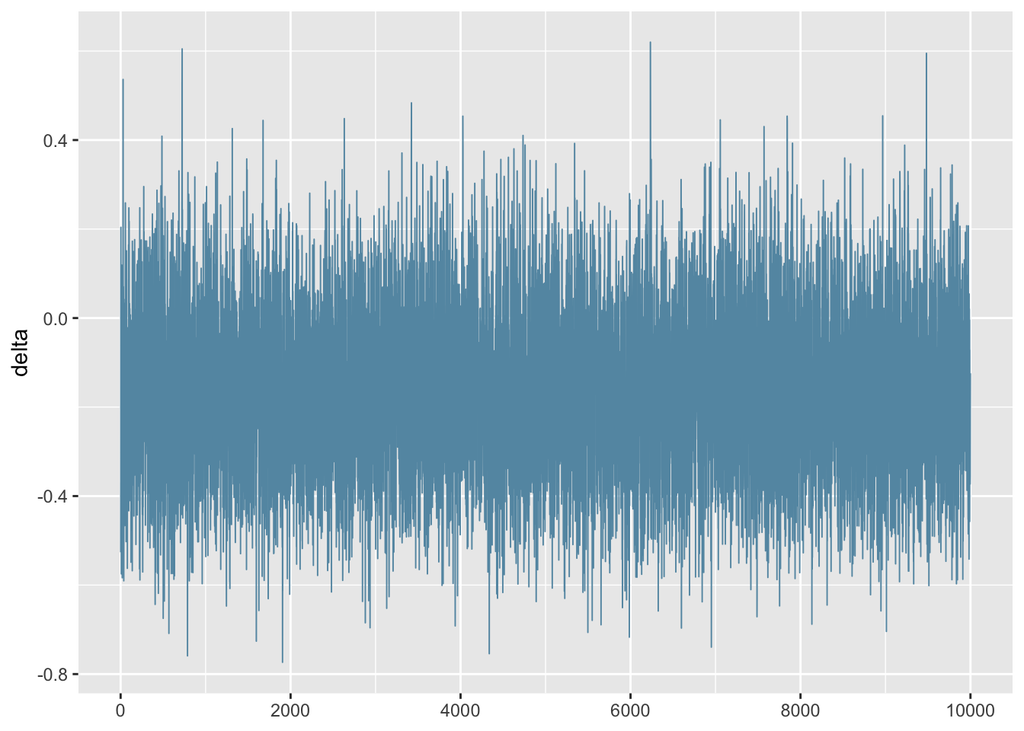

```r
mcmc_trace(samples.mcmc, pars = "delta")
```

```r
# mcmc_trace(samples.mcmc, pars = "delta") %>%
#   gf_facet_grid( chain ~ .) %>%
#   gf_refine(scale_color_viridis_d())
```

# 3 Session Info

```r
sessionInfo()
## R version 4.2.3 (2023-03-15)
## Platform: aarch64-apple-darwin20 (64-bit)
## Running under: macOS Ventura 13.2.1
##
## Matrix products: default
## BLAS:   /Library/Frameworks/R.framework/Versions/4.2-arm64/Resources/lib/libRblas.0.dylib
## LAPACK: /Library/Frameworks/R.framework/Versions/4.2-arm64/Resources/lib/libRlapack.dylib
##
## locale:
## [1] en_US.UTF-8/en_US.UTF-8/en_US.UTF-8/C/en_US.UTF-8/en_US.UTF-8
##
## attached base packages:
## [1] stats     graphics  grDevices utils     datasets  methods   base
##
## other attached packages:
##  [1] cowplot_1.1.1     ggdist_3.2.1      lubridate_1.9.2   forcats_1.0.0
##  [5] stringr_1.5.0     purrr_1.0.1       readr_2.1.4       tidyr_1.3.0
##  [9] tibble_3.2.1      tidyverse_2.0.0   CalvinBayes_0.2.6 bayesplot_1.10.0
## [13] ggformula_0.10.2  ggridges_0.5.4    scales_1.2.1      ggstance_0.3.6
## [17] ggplot2_3.4.1     dplyr_1.1.1       klippy_0.0.0.9500 psych_2.3.3
## [21] R2jags_0.7-1      rjags_4-13        coda_0.19-4       pacman_0.5.1
##
## loaded via a namespace (and not attached):
##   [1] backports_1.4.1      plyr_1.8.8           igraph_1.4.1
##   [4] crosstalk_1.2.0      rstantools_2.3.0     inline_0.3.19
##   [7] digest_0.6.31        htmltools_0.5.4      fansi_1.0.4
##  [10] magrittr_2.0.3       checkmate_2.1.0      tzdb_0.3.0
##  [13] mosaicCore_0.9.2.1   brms_2.19.0          RcppParallel_5.1.7
##  [16] matrixStats_0.63.0   xts_0.13.0           timechange_0.2.0
##  [19] prettyunits_1.1.1    colorspace_2.1-0     haven_2.5.2
##  [22] xfun_0.37            callr_3.7.3          crayon_1.5.2
##  [25] jsonlite_1.8.4       zoo_1.8-11           glue_1.6.2
##  [28] polyclip_1.10-4      gtable_0.3.3         distributional_0.3.2
##  [31] pkgbuild_1.4.0       rstan_2.21.8         abind_1.4-5
##  [34] mvtnorm_1.1-3        DBI_1.1.3            miniUI_0.1.1.1
##  [37] Rcpp_1.0.10          xtable_1.8-4         HDInterval_0.2.4
##  [40] stats4_4.2.3         StanHeaders_2.21.0-7 DT_0.27
##  [43] htmlwidgets_1.6.2    threejs_0.3.3        posterior_1.4.1
##  [46] ellipsis_0.3.2       pkgconfig_2.0.3      loo_2.5.1
##  [49] farver_2.1.1         sass_0.4.5           utf8_1.2.3
##  [52] tidyselect_1.2.0     labeling_0.4.2       rlang_1.1.0
##  [55] reshape2_1.4.4       later_1.3.0          munsell_0.5.0
##  [58] tools_4.2.3          cachem_1.0.7         cli_3.6.0
##  [61] generics_0.1.3       broom_1.0.4          evaluate_0.20
##  [64] fastmap_1.1.1        yaml_2.3.7           processx_3.8.0
##  [67] knitr_1.42           tidygraph_1.2.3      nlme_3.1-162
##  [70] mime_0.12            compiler_4.2.3       shinythemes_1.2.0
##  [73] rstudioapi_0.14      tweenr_2.0.2         bslib_0.4.2
##  [76] stringi_1.7.12       highr_0.10           ps_1.7.3
##  [79] Brobdingnag_1.2-9    lattice_0.20-45      Matrix_1.5-3
##  [82] markdown_1.5         shinyjs_2.1.0        tensorA_0.36.2
##  [85] vctrs_0.6.1          pillar_1.9.0         lifecycle_1.0.3
##  [88] jquerylib_0.1.4      bridgesampling_1.1-2 httpuv_1.6.9
##  [91] R2WinBUGS_2.1-21     R6_2.5.1             promises_1.2.0.1
##  [94] gridExtra_2.3        codetools_0.2-19     boot_1.3-28.1
##  [97] colourpicker_1.2.0   MASS_7.3-58.3        gtools_3.9.4
## [100] assertthat_0.2.1     withr_2.5.0          ggdag_0.2.8
## [103] shinystan_2.6.0      mnormt_2.1.1         parallel_4.2.3
## [106] hms_1.1.3            grid_4.2.3           labelled_2.10.0
## [109] rmarkdown_2.20       ggforce_0.4.1        shiny_1.7.4
## [112] base64enc_0.1-3      dygraphs_1.1.1.6
```